# Elderly Paper - data analysis

W. Francuzik

21.08.2018

# Loading the data

Registered cases 10212

Cases after getting rid of some low-reporting countries 10203

Cases with severity of `>= II` 9415

Children 2524, adults 6891,

Adults 18-64 = 5768 Elderly >=65 = 1123

```
##
##          adult elderly
##   female  3374     606
##   male    2394     517
```

```
##
##              adult   elderly
##   female 0.8477387 0.1522613
##   male   0.8223978 0.1776022
```

```
##
##  Pearson's Chi-squared test with Yates' continuity correction
##
## data:  d.rm$b_sex and d.rm$ages
## X-squared = 7.7302, df = 1, p-value = 0.00543
```

There were significantly more males in the elderly group

# Atopic dermatitis

```
##
##              adult elderly
##   atopic      1628     190
##   non-atopic  4140     933
```

```
##
##                  adult   elderly
##   atopic     0.8954895 0.1045105
##   non-atopic 0.8160852 0.1839148
```

```
##
##  Pearson's Chi-squared test with Yates' continuity correction
##
## data:  d.rm$d_410_atopic and d.rm$ages
## X-squared = 61.281, df = 1, p-value = 0.000000000000004947
```

Signif. more non atopics in the elderly.

# Cardiovascular disease

```
##
##           adult elderly
##   no       4479     440
##   yes       960     641
##   unknown   329      42
```

```
##
##                adult    elderly
##   no      0.91055092 0.08944908
##   yes     0.59962523 0.40037477
##   unknown 0.88679245 0.11320755
```

```
##
##  Pearson's Chi-squared test with Yates' continuity correction
##
## data:  d.rm$q_410_cardio_cur[d.rm$q_410_cardio_cur %in% c("no", "yes")] %>%
##     {
##         as.character(.)
##     } and d.rm$ages[d.rm$q_410_cardio_cur %in% c("no", "yes")]
## X-squared = 842.03, df = 1, p-value < 0.00000000000000022
```

# Urticaria

```
##
##           adult elderly
##   no       5335    1067
##   yes       104      14
##   unknown   329      42
```

```
##
##               adult   elderly
##   no      0.8333333 0.1666667
##   yes     0.8813559 0.1186441
##   unknown 0.8867925 0.1132075
```

```
##
##  Pearson's Chi-squared test with Yates' continuity correction
##
## data:  val[which(val %in% c("no", "yes"))] %>% as.character() and d.rm$ages[which(val %in% c("no", "yes"))]
## X-squared = 1.6003, df = 1, p-value = 0.2059
```

# Mastocytosis

```
##
##           adult elderly
##   no       5303    1042
##   yes       136      39
##   unknown   329      42
```

```
##
##  Pearson's Chi-squared test with Yates' continuity correction
##
## data:  val[which(val %in% c("no", "yes"))] %>% as.character() and d.rm$ages[which(val %in% c("no", "yes"))]
## X-squared = 3.8198, df = 1, p-value = 0.05065
```

# Thyroid disease

```
##
##           adult elderly
##   no       4963     919
##   yes       476     162
##   unknown   329      42
```

```
##
##  Pearson's Chi-squared test with Yates' continuity correction
##
## data:  val[which(val %in% c("no", "yes"))] %>% as.character() and d.rm$ages[which(val %in% c("no", "yes"))]
## X-squared = 39.003, df = 1, p-value = 0.0000000004233
```

# Physical exercise

```
##
##                                                              adult elderly
##   no                                                          3532     737
##   mild eg. walking                                             619     111
##   moderate eg. vigorous housework or gardening                 480      79
##   vigorous eg. running, heavy manual work, competitive sport   510      77
##   unknown                                                      626     119
```

```
## Number of cases in table: 6145
## Number of factors: 2
## Test for independence of all factors:
##  Chisq = 9.806, df = 3, p-value = 0.02029
```

```
##
##  Pairwise comparisons using Pearson's Chi-squared tests
##
## data:  d.rm$ages and d.rm$q_421_exercise
##
##                                                            no
## no                                                         -
## mild eg. walking                                           1.00
## moderate eg. vigorous housework or gardening               0.65
## vigorous eg. running, heavy manual work, competitive sport 0.14
## unknown                                                    1.00
##                                                            mild eg. walking
## no                                                         -
## mild eg. walking                                           -
## moderate eg. vigorous housework or gardening               1.00
## vigorous eg. running, heavy manual work, competitive sport 1.00
## unknown                                                    1.00
##                                                            moderate eg. vigorous housework or gardening
## no                                                         -
## mild eg. walking                                           -
## moderate eg. vigorous housework or gardening               -
## vigorous eg. running, heavy manual work, competitive sport 1.00
## unknown                                                    1.00
##                                                            vigorous eg. running, heavy manual work, competitive sport
## no                                                         -
## mild eg. walking                                           -
## moderate eg. vigorous housework or gardening               -
## vigorous eg. running, heavy manual work, competitive sport -
## unknown                                                    1.00
##                                                            unknown
## no                                                         -
## mild eg. walking                                           -
## moderate eg. vigorous housework or gardening               -
## vigorous eg. running, heavy manual work, competitive sport -
## unknown                                                    -
##
## P value adjustment method: holm
```

# Psychological stress

```
##
##                adult elderly
##   no(unlikely)  5349    1039
##   yes(likely)    418      84
```

```
##
##  Pearson's Chi-squared test with Yates' continuity correction
##
## data:  d.rm$q_422_stress and d.rm$ages
## X-squared = 0.044403, df = 1, p-value = 0.8331
```

# Alcohol

```
##
##           adult elderly
##   no       4280     868
##   yes       326      48
##   unknown  1161     207
```

```
##
##  Pearson's Chi-squared test with Yates' continuity correction
##
## data:  val[which(val %in% c("no", "yes"))] %>% as.character() and d.rm$ages[which(val %in% c("no", "yes"))]
## X-squared = 3.8, df = 1, p-value = 0.05125
```

# Menstruation

```
##
##           adult elderly
##   no       1705     529
##   yes        84       0
##   unknown  1585      77
```

```
##
##  Pearson's Chi-squared test with Yates' continuity correction
##
## data:  val[which(val %in% c("no", "yes"))] %>% as.character() and d.rm$ages[which(val %in% c("no", "yes"))]
## X-squared = 24.446, df = 1, p-value = 0.0000007644
```

This variable should not be taken into account I think. The elderly group does not have any menstrruation…

# infection

```
##
##           adult elderly
##   no       5262    1048
##   yes       177      33
##   unknown   329      42
```

```
##
##  Pearson's Chi-squared test with Yates' continuity correction
##
## data:  val[which(val %in% c("no", "yes"))] %>% as.character() and d.rm$ages[which(val %in% c("no", "yes"))]
## X-squared = 0.061751, df = 1, p-value = 0.8038
```

# repeated reaction

```
##
##           adult elderly
##   no       3454     694
##   yes      1718     314
##   unknown   595     115
```

```
##
##  Pearson's Chi-squared test with Yates' continuity correction
##
## data:  val[which(val %in% c("no", "yes"))] %>% as.character() and d.rm$ages[which(val %in% c("no", "yes"))]
## X-squared = 1.5401, df = 1, p-value = 0.2146
```

# Elicitors

## Total

```
## [[1]]
## [1] "q_310_trigger"
##
## [[2]]
##
##                        adult elderly
##   no                     372      51
##   yes                   4242     883
##   reasonable suspicion  1154     189
##
## [[3]]
##
##  Pairwise comparisons using Pearson's Chi-squared tests
##
## data:  d.rm[selector, x] %>% as.character and d.rm$ages[selector] %>% as.character
##
##         adult  elderly
## adult   -      -
## elderly 0.0011 -
##
## P value adjustment method: holm
```

## Elicitor known

```
## [[1]]
## [1] "elicitor_known"
##
## [[2]]
##
##       adult elderly
##   no   1526     240
##   yes  4242     883
##
## [[3]]
##
##  Pairwise comparisons using Pearson's Chi-squared tests
##
## data:  d.rm[selector, x] %>% as.character and d.rm$ages[selector] %>% as.character
##
##         adult   elderly
## adult   -       -
## elderly 0.00041 -
##
## P value adjustment method: holm
```

## Elicitor suspected

```
## [[1]]
## [1] "elicitor_suspected"
##
## [[2]]
##
##       adult elderly
##   no   4614     934
##   yes  1154     189
##
## [[3]]
##
##  Pairwise comparisons using Pearson's Chi-squared tests
##
## data:  d.rm[selector, x] %>% as.character and d.rm$ages[selector] %>% as.character
##
##         adult elderly
## adult   -     -
## elderly 0.016 -
##
## P value adjustment method: holm
```

## Drugs

```
## [[1]]
## [1] "elicitor_drug"
##
## [[2]]
##
##       adult elderly
##   no   4511     838
##   yes  1257     285
##
## [[3]]
##
##  Pairwise comparisons using Pearson's Chi-squared tests
##
## data:  d.rm[selector, x] %>% as.character and d.rm$ages[selector] %>% as.character
##
##         adult  elderly
## adult   -      -
## elderly 0.0094 -
##
## P value adjustment method: holm
```

### analgesics

```
## [[1]]
## [1] "elicitor_analg"
##
## [[2]]
##
##       adult elderly
##   no   5286    1012
##   yes   482     111
##
## [[3]]
##
##  Pairwise comparisons using Pearson's Chi-squared tests
##
## data:  d.rm[selector, x] %>% as.character and d.rm$ages[selector] %>% as.character
##
##         adult elderly
## adult   -     -
## elderly 0.11  -
##
## P value adjustment method: holm
```

### antibiotics

```
## [[1]]
## [1] "elicitor_anty"
##
## [[2]]
##
##       adult elderly
##   no   5395    1044
##   yes   373      79
##
## [[3]]
##
##  Pairwise comparisons using Pearson's Chi-squared tests
##
## data:  d.rm[selector, x] %>% as.character and d.rm$ages[selector] %>% as.character
##
##         adult elderly
## adult   -     -
## elderly 0.52  -
##
## P value adjustment method: holm
```

### Local anesthetics

```
## [[1]]
## [1] "elicitor_LA"
##
## [[2]]
##
##       adult elderly
##   no   5649    1100
##   yes   119      23
##
## [[3]]
##
##  Pairwise comparisons using Pearson's Chi-squared tests
##
## data:  d.rm[selector, x] %>% as.character and d.rm$ages[selector] %>% as.character
##
##         adult elderly
## adult   -     -
## elderly 1     -
##
## P value adjustment method: holm
```

### x-ray (contrast agent)

```
## [[1]]
## [1] "elicitor_contrast"
##
## [[2]]
##
##       adult elderly
##   no   5710    1101
##   yes    58      22
##
## [[3]]
##
##  Pairwise comparisons using Pearson's Chi-squared tests
##
## data:  d.rm[selector, x] %>% as.character and d.rm$ages[selector] %>% as.character
##
##         adult elderly
## adult   -     -
## elderly 0.01  -
##
## P value adjustment method: holm
```

### PPI

```
## [[1]]
## [1] "elicitor_ppi"
##
## [[2]]
##
##       adult elderly
##   no   5735    1114
##   yes    33       9
##
## [[3]]
##
##  Pairwise comparisons using Pearson's Chi-squared tests
##
## data:  d.rm[selector, x] %>% as.character and d.rm$ages[selector] %>% as.character
##
##         adult elderly
## adult   -     -
## elderly 0.49  -
##
## P value adjustment method: holm
```

### Cardiovascular drugs

```
## [[1]]
## [1] "elicitor_cvd"
##
## [[2]]
##
##       adult elderly
##   no   5759    1118
##   yes     9       5
##
## [[3]]
##
##  Pairwise comparisons using Pearson's Chi-squared tests
##
## data:  d.rm[selector, x] %>% as.character and d.rm$ages[selector] %>% as.character
##
##         adult elderly
## adult   -     -
## elderly 0.11  -
##
## P value adjustment method: holm
```

## Insects

```
## [[1]]
## [1] "elicitor_insects"
##
## [[2]]
##
##       adult elderly
##   no   3059     490
##   yes  2709     633
##
## [[3]]
##
##  Pairwise comparisons using Pearson's Chi-squared tests
##
## data:  d.rm[selector, x] %>% as.character and d.rm$ages[selector] %>% as.character
##
##         adult        elderly
## adult   -            -
## elderly 0.0000000098 -
##
## P value adjustment method: holm
```

### Yellow jacket

```
## [[1]]
## [1] "elicitor_yj"
##
## [[2]]
##
##       adult elderly
##   no   3831     672
##   yes  1937     451
##
## [[3]]
##
##  Pairwise comparisons using Pearson's Chi-squared tests
##
## data:  d.rm[selector, x] %>% as.character and d.rm$ages[selector] %>% as.character
##
##         adult    elderly
## adult   -        -
## elderly 0.000026 -
##
## P value adjustment method: holm
```

### Bee

```
## [[1]]
## [1] "elicitor_bee"
##
## [[2]]
##
##       adult elderly
##   no   5256    1026
##   yes   512      97
##
## [[3]]
##
##  Pairwise comparisons using Pearson's Chi-squared tests
##
## data:  d.rm[selector, x] %>% as.character and d.rm$ages[selector] %>% as.character
##
##         adult elderly
## adult   -     -
## elderly 0.84  -
##
## P value adjustment method: holm
```

### Hornet

```
## [[1]]
## [1] "elicitor_hornet"
##
## [[2]]
##
##       adult elderly
##   no   5615    1067
##   yes   153      56
##
## [[3]]
##
##  Pairwise comparisons using Pearson's Chi-squared tests
##
## data:  d.rm[selector, x] %>% as.character and d.rm$ages[selector] %>% as.character
##
##         adult    elderly
## adult   -        -
## elderly 0.000045 -
##
## P value adjustment method: holm
```

## Food

```
## [[1]]
## [1] "elicitor_food"
##
## [[2]]
##
##       adult elderly
##   no   4514    1001
##   yes  1254     122
##
## [[3]]
##
##  Pairwise comparisons using Pearson's Chi-squared tests
##
## data:  d.rm[selector, x] %>% as.character and d.rm$ages[selector] %>% as.character
##
##         adult               elderly
## adult   -                   -
## elderly <0.0000000000000002 -
##
## P value adjustment method: holm
```

### wheat

```
## [[1]]
## [1] "elicitor_wheat"
##
## [[2]]
##
##       adult elderly
##   no   1077     105
##   yes   177      17
##
## [[3]]
##
##  Pairwise comparisons using Pearson's Chi-squared tests
##
## data:  d.rm.f[selector, x] and d.rm.f$ages[selector]
##
##         adult elderly
## adult   -     -
## elderly 1     -
##
## P value adjustment method: holm
```

### hazelnut

```
## [[1]]
## [1] "elicitor_HN"
##
## [[2]]
##
##       adult elderly
##   no   1170     106
##   yes    84      16
##
## [[3]]
##
##  Pairwise comparisons using Pearson's Chi-squared tests
##
## data:  d.rm.f[selector, x] and d.rm.f$ages[selector]
##
##         adult elderly
## adult   -     -
## elderly 0.015 -
##
## P value adjustment method: holm
```

### soy

```
## [[1]]
## [1] "elicitor_soy"
##
## [[2]]
##
##       adult elderly
##   no   1176     116
##   yes    78       6
##
## [[3]]
##
##  Pairwise comparisons using Pearson's Chi-squared tests
##
## data:  d.rm.f[selector, x] and d.rm.f$ages[selector]
##
##         adult elderly
## adult   -     -
## elderly 0.71  -
##
## P value adjustment method: holm
```

### celery

```
## [[1]]
## [1] "elicitor_celery"
##
## [[2]]
##
##       adult elderly
##   no   1180     115
##   yes    74       7
##
## [[3]]
##
##  Pairwise comparisons using Pearson's Chi-squared tests
##
## data:  d.rm.f[selector, x] and d.rm.f$ages[selector]
##
##         adult elderly
## adult   -     -
## elderly 1     -
##
## P value adjustment method: holm
```

### shellfish

```
## [[1]]
## [1] "elicitor_shellfish"
##
## [[2]]
##
##       adult elderly
##   no   1131     107
##   yes   123      15
##
## [[3]]
##
##  Pairwise comparisons using Pearson's Chi-squared tests
##
## data:  d.rm.f[selector, x] and d.rm.f$ages[selector]
##
##         adult elderly
## adult   -     -
## elderly 0.47  -
##
## P value adjustment method: holm
```

### peanut

```
## [[1]]
## [1] "elicitor_peanut"
##
## [[2]]
##
##       adult elderly
##   no   1186     121
##   yes    68       1
##
## [[3]]
##
##  Pairwise comparisons using Pearson's Chi-squared tests
##
## data:  d.rm.f[selector, x] and d.rm.f$ages[selector]
##
##         adult elderly
## adult   -     -
## elderly 0.045 -
##
## P value adjustment method: holm
```

## Immunotherapy (SIT)

```
## [[1]]
## [1] "elicitor_SIT"
##
## [[2]]
##
##       adult elderly
##   no   5705    1118
##   yes    63       5
##
## [[3]]
##
##  Pairwise comparisons using Pearson's Chi-squared tests
##
## data:  d.rm[selector, x] %>% as.character and d.rm$ages[selector] %>% as.character
##
##         adult elderly
## adult   -     -
## elderly 0.066 -
##
## P value adjustment method: holm
```

# Plots

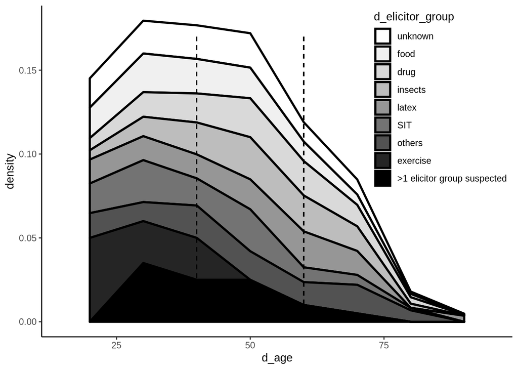

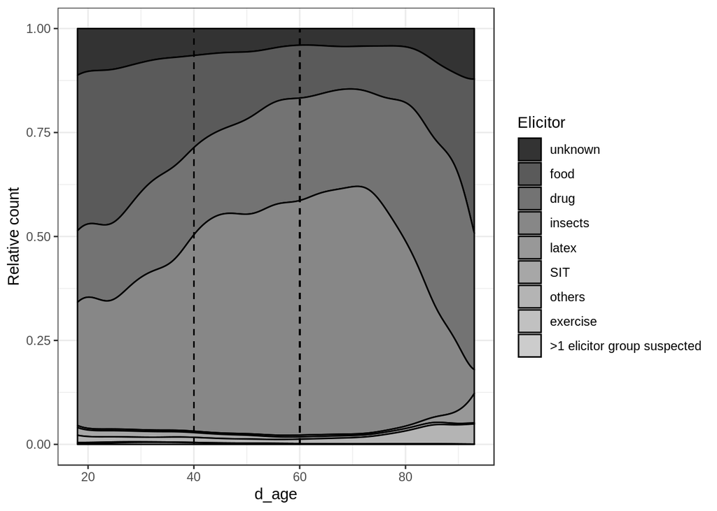

So we can do it - the question now is what do we want to display? Food? or any other variables here that may be of interest?

Second plot - symptoms

## Gastrointestinal

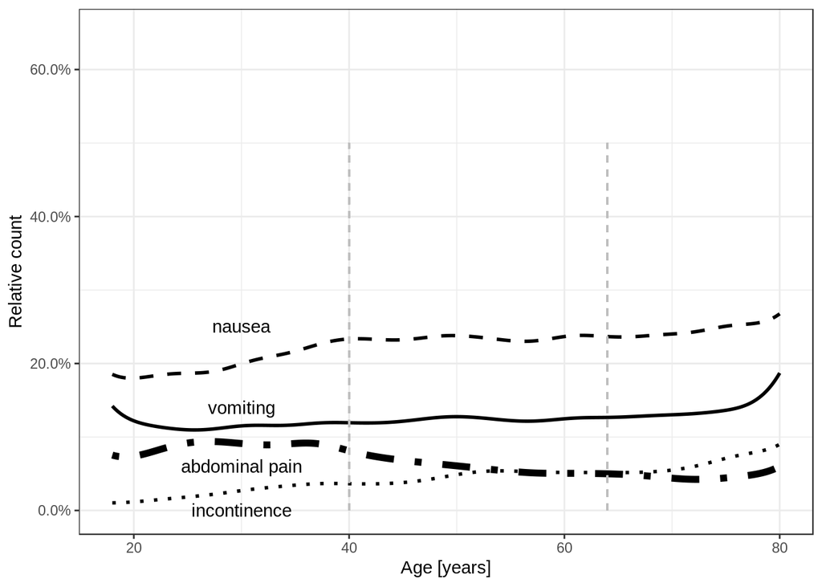

## Skin

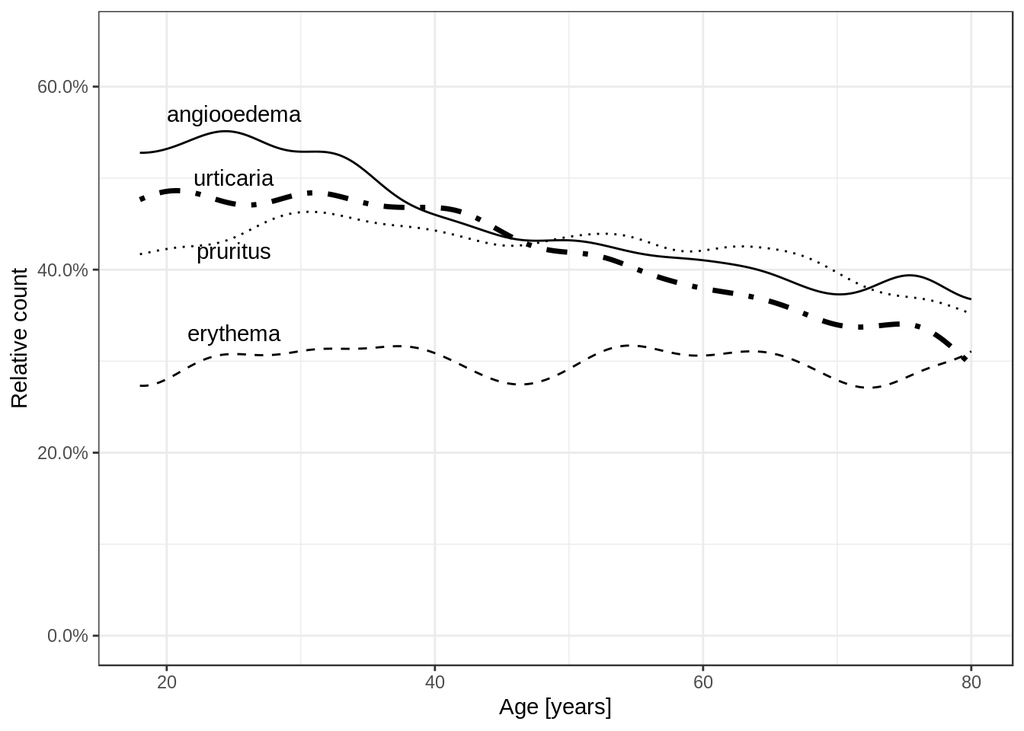

## Respiratory

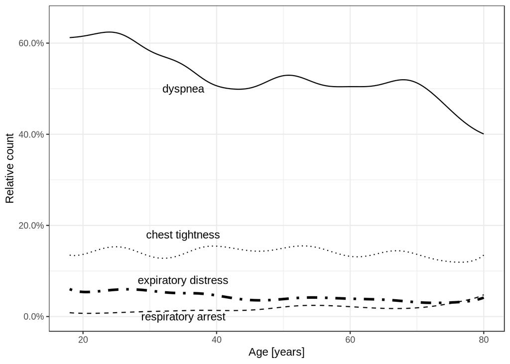

## Cardiac

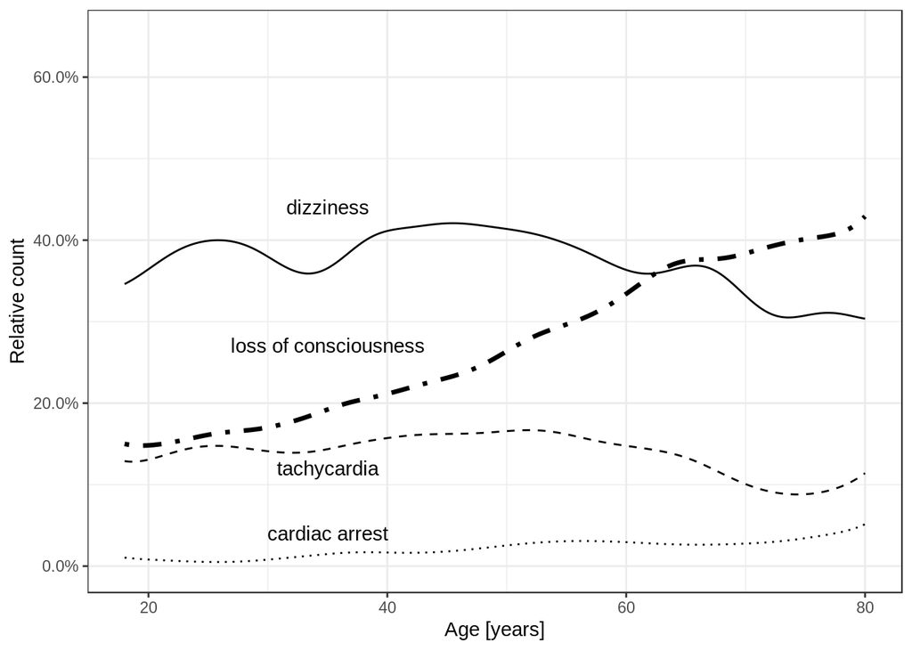

# Risk of developing a biphasic reaction

## with concomitant hypotension

left Biphasic, top - Hypotension as a symptom. Alle cases, no age differentiation:

```
## Number of cases in table: 4940
## Number of factors: 2
## Test for independence of all factors:
##  Chisq = 1.738, df = 1, p-value = 0.1874
```

## with unknown trigger as an elicitor

Unknown elicitor showed relevant meanig that unknown trigger-cases were more often connected with biphasic reactions

```
##
##         no  yes
##   no   292 3588
##   yes   25  148
```

```
##               Trigger
## Biphasic          unknown      known
##   not biphasic 0.92113565 0.96038544
##   biphasic     0.07886435 0.03961456
```

```
## Number of cases in table: 4053
## Number of factors: 2
## Test for independence of all factors:
##  Chisq = 11.016, df = 1, p-value = 0.0009031
```

## Biphasic reaction depending on the trigger group

```
##
##             -9   no  yes unknown
##   food     206 1067   42      61
##   drugs    240 1150   44     108
##   insects  818 2166   96     261
##   other     38  149   11      10
##   unkown    73  292   25      34
```

```
##
##  Pairwise comparisons using Pearson's Chi-squared tests
##
## data:  tab
##
##         food  drugs insects other unkown
## food    -     -     -       -     -
## drugs   1.000 -     -       -     -
## insects 1.000 1.000 -       -     -
## other   0.639 0.616 0.860   -     -
## unkown  0.035 0.024 0.051   1.000 -
##
## P value adjustment method: holm
```

```
##
##  Pearson's Chi-squared test with Yates' continuity correction
##
## data:  t[c(1, 5), 2:3]
## X-squared = 8.3589, df = 1, p-value = 0.003838
```

# e_423_five most important concomitant drugs - beta ass, ace at2 and ppi

```
##
##       adult elderly
##   no   4777     509
##   yes   991     614
```

```
##
##  Pearson's Chi-squared test with Yates' continuity correction
##
## data:  val[which(val %in% c("no", "yes"))] %>% as.character() and d.rm$ages[which(val %in% c("no", "yes"))]
## X-squared = 737.52, df = 1, p-value < 0.00000000000000022
```

# Differences between Age groups and time to reaction

```
##
##           00 – 10 Minutes 11 - 30 Minutes 31 - 60 Minutes 61 - 120 Minutes
##   adult              2146            1107             371              193
##   elderly             436             199              57               41
##
##           121 – 240 Minutes (2 – 4 hours) more than 240 Minutes
##   adult                               132                   130
##   elderly                              29                    21
```

```
##
##  Pairwise comparisons using Pearson's Chi-squared tests
##
## data:  tab
##
##                                 00 – 10 Minutes 11 - 30 Minutes
## 00 – 10 Minutes                 -               -
## 11 - 30 Minutes                 1               -
## 31 - 60 Minutes                 1               1
## 61 - 120 Minutes                1               1
## 121 – 240 Minutes (2 – 4 hours) 1               1
## more than 240 Minutes           1               1
##                                 31 - 60 Minutes 61 - 120 Minutes
## 00 – 10 Minutes                 -               -
## 11 - 30 Minutes                 -               -
## 31 - 60 Minutes                 -               -
## 61 - 120 Minutes                1               -
## 121 – 240 Minutes (2 – 4 hours) 1               1
## more than 240 Minutes           1               1
##                                 121 – 240 Minutes (2 – 4 hours)
## 00 – 10 Minutes                 -
## 11 - 30 Minutes                 -
## 31 - 60 Minutes                 -
## 61 - 120 Minutes                -
## 121 – 240 Minutes (2 – 4 hours) -
## more than 240 Minutes           1
##                                 more than 240 Minutes
## 00 – 10 Minutes                 -
## 11 - 30 Minutes                 -
## 31 - 60 Minutes                 -
## 61 - 120 Minutes                -
## 121 – 240 Minutes (2 – 4 hours) -
## more than 240 Minutes           -
##
## P value adjustment method: holm
```

# Table 3

```
##   grade I  grade II grade III  grade IV
##         0      4055         0         0
```

```
## $`grade I`
##   grade I  grade II grade III  grade IV
##         0         0         0         0
##
## $`grade II`
##   grade I  grade II grade III  grade IV
##         0      4055         0         0
##
## $`grade III`
##   grade I  grade II grade III  grade IV
##         0         0      2630         0
##
## $`grade IV`
##   grade I  grade II grade III  grade IV
##         0         0         0       206
```

```
##
##                                           adult    elderly
##   no treatment                       0.07004161 0.07658059
##   solely lay                         0.07680305 0.04185218
##   solely professional                0.74757282 0.80053428
##   first lay followed by professional 0.04126214 0.02849510
##   unknown                            0.06432039 0.05253785
```

```
##
## Call:
## glm(formula = d.rm$ages %>% factor() ~ d_severity_rm + q_510_first,
##     family = "binomial", data = d.rm)
##
## Deviance Residuals:
##     Min       1Q   Median       3Q      Max
## -0.7660  -0.6851  -0.5563  -0.5006   2.2428
##
## Coefficients:
##                                               Estimate Std. Error z value
## (Intercept)                                   -1.72430    0.12240 -14.088
## d_severity_rmgrade III                         0.45767    0.06718   6.813
## d_severity_rmgrade IV                          0.64835    0.17179   3.774
## q_510_firstsolely lay                         -0.70659    0.19457  -3.632
## q_510_firstsolely professional                -0.06321    0.12497  -0.506
## q_510_firstfirst lay followed by professional -0.52734    0.22365  -2.358
## q_510_firstunknown                            -0.28943    0.18435  -1.570
##                                                           Pr(>|z|)
## (Intercept)                                   < 0.0000000000000002 ***
## d_severity_rmgrade III                            0.00000000000957 ***
## d_severity_rmgrade IV                                     0.000161 ***
## q_510_firstsolely lay                                     0.000282 ***
## q_510_firstsolely professional                            0.613019
## q_510_firstfirst lay followed by professional             0.018382 *
## q_510_firstunknown                                        0.116411
## ---
## Signif. codes:  0 '***' 0.001 '**' 0.01 '*' 0.05 '.' 0.1 ' ' 1
##
## (Dispersion parameter for binomial family taken to be 1)
##
##     Null deviance: 6126.9  on 6890  degrees of freedom
## Residual deviance: 6045.4  on 6884  degrees of freedom
## AIC: 6059.4
##
## Number of Fisher Scoring iterations: 4
```

Here we see that if we adjust the treatment of a given reaction to severity (so the severity among adults and elderly is cosidered the same), elderly had less reactions that were treated solely by lay persons, or lay + profesionnal. This is interesting..

```
##
##   adult elderly
##    5768    1123
```

```
##
##     adult   elderly
## 0.8370338 0.1629662
```

```
##      ages    d_age
## 1   adult 43.31987
## 2 elderly 71.03829
```

```
## # A tibble: 2 x 3
##   ages        m    sd
##   <chr>   <dbl> <dbl>
## 1 adult    43.3 12.7
## 2 elderly  71.0  4.84
```

```
##
##          adult elderly
##   female  3374     606
##   male    2394     517
```

```
##
##              adult   elderly
##   female 0.5849515 0.5396260
##   male   0.4150485 0.4603740
```

[output not shown]